# Final Project

Lauren Walko

November 13, 2020

# Guiding Question

## Does mask wearing have an effect on the amount of positive COVID-19 cases in a State?

### Load packages

```r
library(DataComputing)
library(tidyverse)
library(mosaic)
library(ggplot2)
```

### Load and inspect the data

#### Mask data

This data came from a survey regarding mask wearing in an area. This data will be used to determine the average responses for each state.

```r
masks <- read.csv("/home/ltw5073/Final Project/masks.csv")
head(masks)
```

|  | COUNTYFP | NEVER | RARELY | SOMETIMES | FREQUENTLY | ALWAYS |
| --- | --- | --- | --- | --- | --- | --- |
| 1 | 1001 | 0.053 | 0.074 | 0.134 | 0.295 | 0.444 |
| 2 | 1003 | 0.083 | 0.059 | 0.098 | 0.323 | 0.436 |
| 3 | 1005 | 0.067 | 0.121 | 0.120 | 0.201 | 0.491 |
| 4 | 1007 | 0.020 | 0.034 | 0.096 | 0.278 | 0.572 |
| 5 | 1009 | 0.053 | 0.114 | 0.180 | 0.194 | 0.459 |
| 6 | 1011 | 0.031 | 0.040 | 0.144 | 0.286 | 0.500 |

#### Cases data

This data comes shows the increase in cases each day for each state.

```r
cases <- read.csv("/home/ltw5073/Final Project/cases.csv")
head(cases)
```

|  | date | state | cases | daily.increase |
| --- | --- | --- | --- | --- |
| 1 | 1/21/20 | Washington | 1 | 1 |
| 2 | 1/22/20 | Washington | 1 | 0 |
| 3 | 1/23/20 | Washington | 1 | 0 |
| 4 | 1/24/20 | Illinois | 1 | 1 |
| 5 | 1/24/20 | Washington | 1 | 0 |
| 6 | 1/25/20 | California | 1 | 1 |

#### County Fips data

This data set will be used to match the zip codes with each state to help determine how each state responded.

```r
fips <- read.csv("/home/ltw5073/Final Project/countyfips.csv")
glimpse(fips)
```

```
Observations: 52,889
Variables: 5
$ ZIP        <int> 36003, 36006, 36067, 36066, 36703, 36701, 36091, 36051, 36068, 36008, 36022, 36…
$ COUNTYNAME <fct> Autauga County, Autauga County, Autauga County, Autauga County, Autauga County,…
$ STATE      <fct> AL, AL, AL, AL, AL, AL, AL, AL, AL, AL, AL, AL, AL, AL, AL, AL, AL, AL, AL, AL,…
$ STCOUNTYFP <int> 1001, 1001, 1001, 1001, 1001, 1001, 1001, 1001, 1001, 1001, 1001, 1001, 1001, 1…
$ CLASSFP    <fct> H1, H1, H1, H1, H1, H1, H1, H1, H1, H1, H1, H1, H1, H1, H1, H1, H1, H1, H1, H1,…
```

#### ZipGeography data

This data set is used to find population for each state.

```r
data("ZipGeography")
nrow(ZipGeography)
```

```
[1] 42741
```

#### States data

I will need this later in my project to join the data sets together with one being abbreviations and the other being the full state name.

```r
stabr <- read.csv("/home/ltw5073/Final Project/States.csv")
str(stabr)
```

```
'data.frame':   101 obs. of  2 variables:
 $ State       : Factor w/ 51 levels "","Alabama","Alaska",..: 2 3 4 5 6 7 8 9 10 11 ...
 $ Abbreviation: Factor w/ 51 levels "","AK","AL","AR",..: 3 2 5 4 6 7 8 9 10 11 ...
```

### Match the fip codes in the mask data to zip codes in the county fips data

```r
ZipCodes <-
  masks %>%
  select(COUNTYFP, NEVER, RARELY, SOMETIMES, FREQUENTLY, ALWAYS) %>%
  left_join(fips %>% select(ZIP, STATE, STCOUNTYFP),
            by = c("COUNTYFP" = "STCOUNTYFP"))
```

### Sort the mask data by state and find the average for each response for each state

```r
ZipCodes$STATE <- forcats::fct_explicit_na(ZipCodes$STATE) #Removes missing data from dataset
States <-
  ZipCodes %>%
  group_by(STATE) %>%
  summarise(Never = mean(NEVER),
            Rarely = mean(RARELY),
            Sometimes = mean(SOMETIMES),
            Frequently = mean(FREQUENTLY),
            Always = mean(ALWAYS))
```

### Match the state abbreviation with full name of state for later joining

```r
States <-
  States %>%
  select(Never, Rarely, Sometimes, Frequently, Always, STATE) %>%
  left_join(stabr %>% select(State, Abbreviation),
            by = c("STATE" = "Abbreviation"))
```

#### Show the mask wearing frequencies in descending order by “Never” response

```r
States %>%
  arrange(desc(Never))
```

| Never | Rarely | Sometimes | Frequently | Always | STATE | State |
| --- | --- | --- | --- | --- | --- | --- |
| 0.17319206 | 0.158660317 | 0.14653175 | 0.2493794 | 0.2722254 | ND | North Dakota |
| 0.15021322 | 0.117981818 | 0.16920331 | 0.2096793 | 0.3530430 | SD | South Dakota |
| 0.14875591 | 0.166801181 | 0.14371850 | 0.2118504 | 0.3289173 | MT | Montana |
| 0.14421860 | 0.156167442 | 0.12244651 | 0.2325023 | 0.3447581 | WY | Wyoming |
| 0.12650000 | 0.048500000 | 0.07300000 | 0.4010000 | 0.3510000 | (Missing) | NA |
| 0.12191527 | 0.114497613 | 0.14230847 | 0.2089087 | 0.4123288 | MO | Missouri |
| 0.11257835 | 0.108667010 | 0.14344124 | 0.2616062 | 0.3737433 | NE | Nebraska |
| 0.10060660 | 0.134969543 | 0.14499492 | 0.2254975 | 0.3939518 | ID | Idaho |
| 0.09982882 | 0.104452402 | 0.14084367 | 0.2199450 | 0.4349301 | KS | Kansas |
| 0.09870833 | 0.090242647 | 0.14467729 | 0.2110212 | 0.4554943 | TN | Tennessee |

[output cut: 42 more lines]

### Determine the cumulative amount of cases that each state has had

```r
caseperstate <-
  cases %>%
  group_by(state) %>%
  summarise(cases = sum(daily.increase))
```

#### Arrange the cumulative cases in descending order

```r
caseperstate %>%
  arrange(desc(cases))
```

| state | cases |
| --- | --- |
| California | 1371940 |
| Texas | 1344195 |
| Florida | 1058066 |
| Illinois | 788922 |
| New York | 710612 |
| Georgia | 483106 |
| Ohio | 475024 |
| Wisconsin | 441067 |
| Michigan | 426124 |
| Pennsylvania | 423828 |

[output cut: 46 more lines]

#### Create a bar graph with states that have more than 400,000 cases.

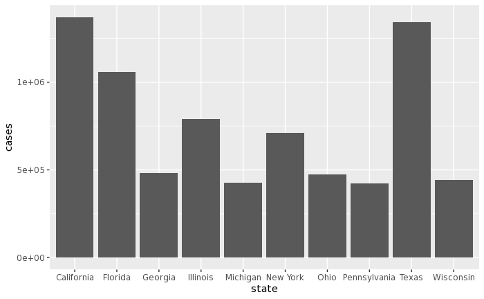

```r
caseperstate %>%
  filter(cases > 400000) %>%
  ggplot(aes(x=state, y=cases)) +
  geom_bar(stat = 'identity',position='dodge',width=.9)
```

This graph shows that California, Florida, Georgia, Illinois, Michigan, New York, Ohio, Pennsylvania, Texas, and Wisconsin have the highest cumulative amount of cases. However, population is an important factor, so I am going to look at the population for each of the states.

### Determine population per state and determine the percent of positive cases per state

#### Find state population

```r
ZipGeography$State <- forcats::fct_explicit_na(ZipGeography$State) #Removes missing data from dataset
Population <-
  ZipGeography %>%
  group_by(State) %>%
  summarise(Pop = sum(Population, na.rm=TRUE))
Population %>%
  arrange(desc(Pop))
```

| State | Pop |
| --- | --- |
| California | 33864430 |
| Texas | 20835778 |
| New York | 18974619 |
| Florida | 15979631 |
| Illinois | 12419037 |
| Pennsylvania | 12280587 |
| Ohio | 11353002 |
| Michigan | 9938204 |
| New Jersey | 8413990 |
| Georgia | 8185503 |

[output cut: 43 more lines]

I am not surprised by what I have found, as the states with the highest population are what was found to have the highest cumulative number of cases.

### Find percent positive for each state

A more effective way to look at the data to compare with the mask wearing data set is to find the percent positive per state.

```r
PercentPositive <-
  Population %>%
  select(State, Pop) %>%
  left_join(caseperstate %>% select(state, cases),
            by = c("State" = "state")) %>%
  mutate(PositivePercent = (cases / Pop)*100)
```

#### Arrange the percent positive for each state in descending order

```r
PercentPositive %>%
  arrange(desc(PositivePercent))
```

| State | Pop | cases | PositivePercent |
| --- | --- | --- | --- |
| North Dakota | 641427 | 82987 | 12.9378713 |
| South Dakota | 752418 | 85991 | 11.4286208 |
| Utah | 2230615 | 215407 | 9.6568435 |
| Idaho | 1292218 | 110553 | 8.5552902 |
| Nevada | 1993290 | 168758 | 8.4663045 |
| Iowa | 2892853 | 244689 | 8.4583973 |
| Wisconsin | 5363662 | 441067 | 8.2232437 |
| Nebraska | 1703958 | 139834 | 8.2064229 |
| Montana | 900653 | 67875 | 7.5361987 |
| Wyoming | 491229 | 36317 | 7.3930896 |

[output cut: 43 more lines]

#### Plot the positive percents with states that have a positive percent above 8.00%

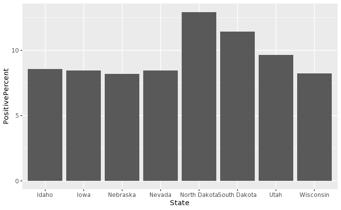

```r
PercentPositive %>%
  filter(PositivePercent > 8) %>%
  ggplot(aes(x=State,y=PositivePercent)) +
  geom_bar(stat = 'identity',position='dodge',width=.9)
```

### Plot the percent positive cases versus the Never result from survey

```r
Covid <-
  PercentPositive %>%
  select(State, PositivePercent) %>%
  left_join(States %>% select(Never, State),
            by = c("State" = "State"))
```

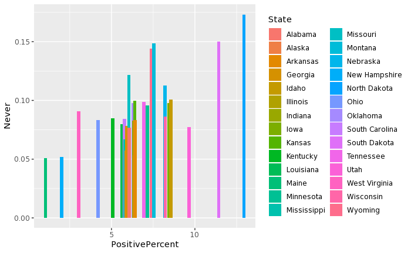

```r
Covid %>%
  filter(Never > 0.05) %>%
  ggplot(aes(x=PositivePercent, y=Never, fill=State)) +
  geom_bar(stat = 'identity', position = 'dodge', width = .2)
```

This graph shows an interesting pattern because it appears a high positive percent has a higher “Never” response, but I want to look at the linear regression of the data to make my final determinations.

### Find the correlation between positive percent and the “Never” response

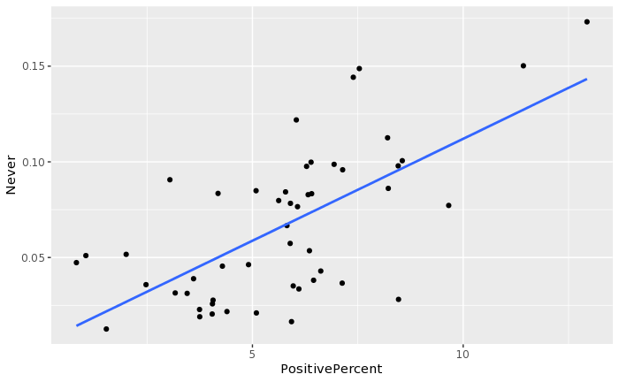

```r
Covid %>%
  ggplot(aes(x=PositivePercent, y=Never)) +
  geom_point() +
  geom_smooth(method = "lm", se = FALSE)
```

### Find r^2 value

```r
fit1 <- lm(Covid$PositivePercent ~ Covid$Never)
summary(fit1)
```

```
Call:
lm(formula = Covid$PositivePercent ~ Covid$Never)

Residuals:
    Min      1Q  Median      3Q     Max
-4.1206 -0.9669 -0.0407  1.4133  4.2888

Coefficients:
            Estimate Std. Error t value Pr(>|t|)
(Intercept)   3.0552     0.5146   5.937 3.13e-07 ***
Covid$Never  39.9119     6.6972   5.960 2.89e-07 ***
---
Signif. codes:  0 ‘***’ 0.001 ‘**’ 0.01 ‘*’ 0.05 ‘.’ 0.1 ‘ ’ 1

Residual standard error: 1.85 on 48 degrees of freedom
  (3 observations deleted due to missingness)
Multiple R-squared:  0.4253,    Adjusted R-squared:  0.4133
F-statistic: 35.52 on 1 and 48 DF,  p-value: 2.891e-07
```